# Comparative heatmap

Ellen Dimmen Chapple

2023-08-25

```r
library(dplyr)
library(tidyr)
library(ggplot2)
library(ComplexHeatmap)
library(tibble)
library(reshape2)
library(cowplot)
```

**Flow**

- Load expression datasets for: Aspen (AspWood) Norway Spruce (NorWood) and Scots Pine (ScotsWood)
- Load comparison table which contains the various genes within each ortholog group for both species. The p-value for each ortholog pair is calculated (both directions), and then the highest of these two is used for ‘Max.p.val’.
- Extract the lowest ‘Max.p.val.’ from each ortholog group with the corresponding ortholog pair.
- Filter the expression data to only include genes that are from the lowest p-value ortholog pairs. The rows in the expression data sets must also be ordered the same so that the gene in row 10 in species 1 will have its ortholog pair in row 10 in species 2.
- Create a correlation matrix using the filtered and sorted/ordered expression data.
- Create heatmap.

# 1 Loading the transcription data

```r
# AspWood
asp_expr_data <- read.delim ("Data/DATA/AspWood_transcriptomics.txt")


# NorWood
nor_expr_data <- read.delim("Data/DATA/NorWood_transcriptomics.txt")

# ScotsWood (Pinus Sylvestris, Scots Pine, Furu)
scots_expr_data <- read.delim("Data/DATA/ScotsWood_transcriptomics.txt")

cat("AspWood - # of genes: ", dim(asp_expr_data)[1],"\nNorWood - # of genes: ", dim(nor_expr_data)[1], "\nScotsWood - # of genes: ", dim(scots_expr_data)[1])
```

```
## AspWood - # of genes:  23246
## NorWood - # of genes:  18401
## ScotsWood - # of genes:  16841
```

# 2 Selecting ortholog pairs with lowest max p-value

- ‘Max.p.val’ needs to be numeric.
- Use distinct() to avoid the same gene appearing in the different OGs - this will otherwise cause the filtered expression data sets to have different row lengths which is needed for making correlation matrix. However, must be used after picking out the lowest p-values!

NOTES FOR CODE BELOW: Need more compact code that can be used for all species combinations.

```r
load("~/NMBU/M60-BIAS/EvoTree/Data/DATA/comparison-Asp-Nor-pearsonMR0.03no-table.RData")
asp_nor_p.val <- comparison_table%>%
  # ungroup() %>%
  select(Species1, Species2,OrthoGroup, Max.p.val) %>%
  mutate_at("Max.p.val", as.numeric) %>%
  group_by(OrthoGroup) %>%
  arrange(Max.p.val,.by_group = T) %>%
  slice(1) %>%
  ungroup() %>%
  distinct(Species1, .keep_all = T) %>%
  distinct( Species2, .keep_all = T)


# Check the number of unique groups in test set.
cat("Number of orthogroups after removing genes appearing in multiple groups: ", length(unique(asp_nor_p.val$OrthoGroup)) )
```

```
## Number of orthogroups after removing genes appearing in multiple groups:  7192
```

```r
cat("Number of duplicated genes in Asp: ", sum(duplicated(asp_nor_p.val$Species1)), "\nNumber of duplicated genes in Nor: ",sum(duplicated(asp_nor_p.val$Species2)))
```

```
## Number of duplicated genes in Asp:  0
## Number of duplicated genes in Nor:  0
```

```r
# New filtering and sorting - ASP
asp_pval_copy <- asp_nor_p.val

asp_expr_fs <- asp_pval_copy %>%
  left_join(asp_expr_data, join_by(Species1 == Genes)) %>%
  select(-c(2:4)) %>%
  as_tibble() %>%
  column_to_rownames(var = "Species1") %>%
  select(contains("1."))


# New filtering and sorting - NOR

nor_pval_copy <- asp_nor_p.val
nor_expr_fs <- nor_pval_copy %>%
  left_join(nor_expr_data, join_by(Species2 == Genes)) %>%
  select(-c("Species1", "Max.p.val", "OrthoGroup")) %>%
  as_tibble() %>%
  column_to_rownames(var = "Species2") %>%
  select(contains("1."))
# Correlation matrix and heatmap

corr_asp_nor <- round(cor( asp_expr_fs,nor_expr_fs, method = "pearson"), 4)
heat_asp_nor <-  Heatmap(corr_asp_nor, column_title = "Asp-Nor",
    column_title_gp = gpar(fontsize = 15),
    row_names_gp = gpar(fontsize = 8),
    column_names_gp = gpar(fontsize = 8),
    width = ncol(corr_asp_nor)*unit(5, "mm"),
    height = nrow(corr_asp_nor)*unit(5, "mm"),
    row_order = 1:ncol(asp_expr_fs),
    column_order = 1:ncol(nor_expr_fs),
    name = "corr" )

# https://jokergoo.github.io/ComplexHeatmap-reference/book/
```

```r
#------------------ASP-SCOTS------------------
load("~/NMBU/M60-BIAS/EvoTree/Data/DATA/comparison-Asp-Scots-pearsonMR0.03no-table.RData")


asp_scots_p.val <- comparison_table%>%
  # ungroup() %>%
  select(Species1, Species2,OrthoGroup, Max.p.val) %>%
  mutate_at("Max.p.val", as.numeric) %>%
  group_by(OrthoGroup) %>%
  arrange(Max.p.val,.by_group = T) %>%
  slice(1) %>%
  ungroup() %>%
  distinct(Species1, .keep_all = T) %>%
  distinct( Species2, .keep_all = T)
# Check the number of unique groups in test set.

cat("Number of orthogroups after removing genes appearing in multiple groups: ", length(unique(asp_scots_p.val$OrthoGroup)) )
```

```
## Number of orthogroups after removing genes appearing in multiple groups:  7262
```

```r
cat("Number of duplicated genes in Asp: ", sum(duplicated(asp_scots_p.val$Species1)), "\nNumber of duplicated genes in Scots: ",sum(duplicated(asp_scots_p.val$Species2)))
```

```
## Number of duplicated genes in Asp:  0
## Number of duplicated genes in Scots:  0
```

```r
# AspWood filtering and sorting

asp_pval_copy <- asp_scots_p.val
asp_expr_fs <- asp_pval_copy %>%
  left_join(asp_expr_data, join_by(Species1 == Genes)) %>%
  select(-c("Species2", "Max.p.val", "OrthoGroup")) %>%
  as_tibble() %>%
  column_to_rownames(var = "Species1") %>%
  select(contains("1."))


# ScotsWood filtering and sorting

scots_pval_copy <- asp_scots_p.val
scots_expr_fs <- scots_pval_copy %>%
  left_join(scots_expr_data, join_by(Species2 == Genes)) %>%
  select(-c("Species1", "Max.p.val", "OrthoGroup")) %>%
  as_tibble() %>%
  column_to_rownames(var = "Species2") %>%
  select(contains("1."))

# Correlation amd heatmap
corr_asp_scots <- round(cor(asp_expr_fs, scots_expr_fs,method = "pearson"), 4)


heat_asp_scots <-  Heatmap(corr_asp_scots, column_title = "Asp-Scots",
    column_title_gp = gpar(fontsize = 15),
    row_names_gp = gpar(fontsize = 8),
    column_names_gp = gpar(fontsize = 8),
    width = ncol(corr_asp_scots)*unit(5, "mm"),
    height = nrow(corr_asp_scots)*unit(5, "mm"),
    row_order = 1:ncol(asp_expr_fs),
    column_order = 1:ncol(scots_expr_fs),
    name = "corr")
```

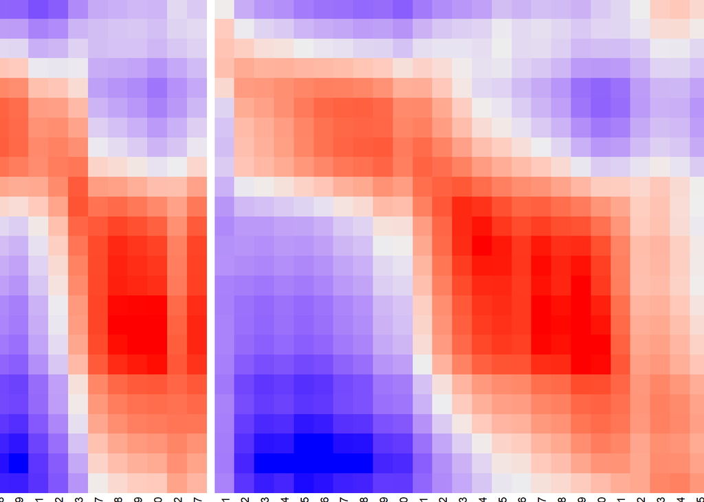

```r
heats <-  heat_asp_nor + heat_asp_scots
heats
```